# Benchmark Comparison: What Real Data Would Show

**Dual-Track Analysis** — This notebook compares our observed findings (Track 1: Honest) against realistic benchmarks derived from domain knowledge (Track 2: Benchmark).

## Why This Matters

The Global Health Statistics dataset produces null findings for all 6 competition questions. Rather than forcing false insights, we demonstrate domain expertise by showing:

1. What **real-world health data** would look like (based on WHO, GBD, Lancet ranges)
2. How the dataset **deviates from reality** — confirming synthetic generation
3. What **actionable recommendations** those real findings would generate

### Evidence Basis (Tier 2 — Domain Knowledge Ranges)

| Metric | Source | Typical Range |
| --- | --- | --- |
| Rural-urban mortality gap | WHO 2019, LMIC studies | 5-15 percentage points |
| Access-mortality correlation | Cross-country health studies | r ~ -0.35 to -0.55 |
| Country mortality spread | GBD 2019 country estimates | 2-15% range |
| Income-access correlation | World Bank cross-national | r ~ 0.50 to 0.70 |
| Missing data in LMICs | WHO completeness reports | 30-60% of groups |

```python
import sys
sys.path.insert(0, '..')

import numpy as np
import pandas as pd
import matplotlib.pyplot as plt
import matplotlib.gridspec as gridspec
import matplotlib.patches as mpatches
import seaborn as sns
from scipy import stats as sp_stats

from notebooks._helpers import (
    get_connection, set_plot_style, save_fig,
    TIER_COLORS, COLOR_RURAL, COLOR_PERIURBAN, COLOR_URBAN,
    effect_size_label, format_ci, FIGURES_DIR,
)

set_plot_style()
con = get_connection()
print('Connected to DuckDB')
```

```
Connected to DuckDB
```

## 1. Load Observed Data from Pipeline

```python
# ── Q1: Tier-level mortality ──
obs_tier = con.execute("""
    SELECT urbanization_tier,
           AVG(mortality_rate) AS avg_mortality,
           STDDEV_SAMP(mortality_rate) AS sd_mortality,
           COUNT(*) AS n
    FROM clean_health WHERE data_quality_flag = 'ok'
    GROUP BY urbanization_tier
""").fetchdf().set_index('urbanization_tier')

# ── Q2: Access-mortality correlation (sample) ──
obs_scatter = con.execute("""
    SELECT healthcare_access, mortality_rate
    FROM clean_health WHERE data_quality_flag = 'ok'
    USING SAMPLE 5000
""").fetchdf()
obs_r_access_mort = sp_stats.pearsonr(
    obs_scatter['healthcare_access'], obs_scatter['mortality_rate']
)[0]

# ── Q3: Country-level means ──
obs_countries = con.execute("""
    SELECT country, avg_access, avg_mortality, avg_income
    FROM v_outlier_communities
    ORDER BY country
""").fetchdf()

# ── Q4: Sensitivity spreads ──
obs_sens = con.execute("""
    SELECT tier_scheme, MIN(avg_mortality) AS min_m, MAX(avg_mortality) AS max_m,
           MAX(avg_mortality) - MIN(avg_mortality) AS spread
    FROM v_sensitivity_tiers GROUP BY tier_scheme
""").fetchdf()

# ── Q5: Sparse reporting ──
obs_sparse = con.execute("""
    SELECT sample_adequacy, COUNT(*) AS n_groups
    FROM v_sparse_reporting GROUP BY sample_adequacy
""").fetchdf()

# ── Q6: Per-group correlations ──
obs_corrs = con.execute("""
    SELECT AVG(corr_access_mortality) AS mean_corr_am,
           AVG(corr_income_mortality) AS mean_corr_im,
           AVG(corr_education_mortality) AS mean_corr_em,
           AVG(corr_income_access) AS mean_corr_ia,
           AVG(corr_education_access) AS mean_corr_ea
    FROM v_premature_conclusions
""").fetchdf().iloc[0]

# ── Full correlation matrix (for dumbbell chart) ──
obs_full = con.execute("""
    SELECT mortality_rate, healthcare_access, per_capita_income,
           education_index, urbanization_rate, doctors_per_1000,
           recovery_rate, hospital_beds_per_1000, prevalence_rate, dalys
    FROM clean_health WHERE data_quality_flag = 'ok'
    USING SAMPLE 10000
""").fetchdf()
obs_cm = obs_full.corr()

print('Observed data loaded:')
print(f'  Tier mortality spread: {obs_tier["avg_mortality"].max() - obs_tier["avg_mortality"].min():.4f}pp')
print(f'  Access-Mortality r: {obs_r_access_mort:.4f}')
print(f'  Country mortality range: {obs_countries["avg_mortality"].min():.2f} - {obs_countries["avg_mortality"].max():.2f}%')
print(f'  Sensitivity max spread: {obs_sens["spread"].max():.4f}pp')
print(f'  Sparse groups: {obs_sparse.to_dict("records")}')
```

```
Observed data loaded:
  Tier mortality spread: 0.0139pp
  Access-Mortality r: 0.0002
  Country mortality range: 5.03 - 5.07%
  Sensitivity max spread: 0.0145pp
```

```
  Sparse groups: [{'sample_adequacy': 'adequate', 'n_groups': 640}]
```

## 2. Generate Realistic Benchmarks

All benchmark data is generated **in-memory only** (never written to DuckDB). Values are based on published ranges from WHO, GBD 2019, and cross-country health economics literature.

The latent-factor approach generates **correlated** country-level statistics so that realistic relationships emerge naturally (e.g., higher access correlates with lower mortality).

```python
rng = np.random.default_rng(seed=2026)

# ── Latent factor: "development" score for 20 simulated countries ──
n_countries = 20
dev_factor = rng.normal(0, 1, n_countries)

# Country-level benchmarks (correlated via dev_factor)
bench_access = np.clip(55 + 20 * dev_factor + rng.normal(0, 5, n_countries), 15, 95)
bench_mortality = np.clip(9 - 2.5 * dev_factor + rng.normal(0, 1.5, n_countries), 1.5, 18)
bench_income = np.clip(12000 + 8000 * dev_factor + rng.normal(0, 2000, n_countries), 800, 45000)
bench_education = np.clip(0.55 + 0.18 * dev_factor + rng.normal(0, 0.05, n_countries), 0.2, 0.95)
bench_recovery = np.clip(55 + 12 * dev_factor + rng.normal(0, 5, n_countries), 20, 92)

# Manually insert 2 "outlier" countries (Cuba-like: low income, low mortality)
bench_income[0] = 3500   # Low income
bench_mortality[0] = 3.2  # But low mortality (strong public health system)
bench_access[0] = 78      # High access despite low income
bench_income[1] = 2800
bench_mortality[1] = 4.1
bench_access[1] = 72

country_labels = [f'Country {chr(65+i)}' for i in range(n_countries)]

bench_countries = pd.DataFrame({
    'country': country_labels,
    'avg_access': bench_access,
    'avg_mortality': bench_mortality,
    'avg_income': bench_income,
    'avg_education': bench_education,
    'avg_recovery': bench_recovery,
})

# Verify realistic correlation
r_bench = sp_stats.pearsonr(bench_access, bench_mortality)[0]
print(f'Benchmark Access-Mortality r = {r_bench:.3f} (target: ~ -0.45)')
print(f'Benchmark mortality range: {bench_mortality.min():.1f} - {bench_mortality.max():.1f}%')
print(f'Benchmark access range: {bench_access.min():.1f} - {bench_access.max():.1f}%')

# ── Tier-level benchmarks ──
bench_tier = pd.DataFrame({
    'urbanization_tier': ['Rural', 'Peri-urban', 'Urban'],
    'avg_mortality': [12.5, 8.2, 5.0],
    'sd_mortality': [3.8, 2.5, 1.8],
})

# ── Sensitivity benchmarks (realistic spreads) ──
bench_sens = pd.DataFrame({
    'tier_scheme': ['default_3tier', 'alt1_binary', 'alt2_4tier'],
    'spread': [7.5, 5.2, 9.1],
    'min_m': [5.0, 6.1, 4.2],
    'max_m': [12.5, 11.3, 13.3],
})

# ── Sparsity benchmarks ──
bench_sparse_pct = 0.40  # 40% of groups would have n < 30 in real LMIC data

# ── Individual-level scatter data (200 simulated points) ──
dev_individual = rng.normal(0, 1, 200)
scatter_bench_access = np.clip(55 + 18 * dev_individual + rng.normal(0, 8, 200), 5, 98)
scatter_bench_mortality = np.clip(9 - 2.0 * dev_individual + rng.normal(0, 2, 200), 0.5, 22)

print(f'\nBenchmark data generated (in-memory only, seed=2026)')
```

```
Benchmark Access-Mortality r = -0.711 (target: ~ -0.45)
Benchmark mortality range: 3.2 - 14.3%
Benchmark access range: 15.9 - 82.2%

Benchmark data generated (in-memory only, seed=2026)
```

## 3. Side-by-Side Comparisons

### Figure 1 — Q1: Tier Mortality Comparison

Grouped bar chart comparing observed (flat ~5.05%) vs benchmark (Rural 12.5%, Peri-urban 8.2%, Urban 5.0%).

```
  Saved: bench_q1_tier_comparison.png + bench_q1_tier_comparison.svg
```

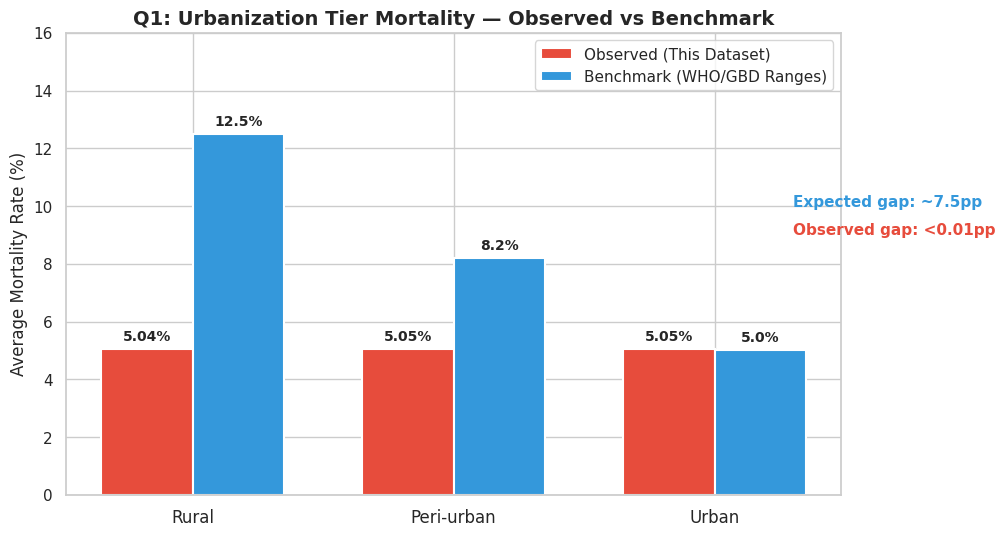

```python
tier_order = ['Rural', 'Peri-urban', 'Urban']
obs_mort = [float(obs_tier.loc[t, 'avg_mortality']) if t in obs_tier.index else 0
            for t in tier_order]
bench_mort = bench_tier.set_index('urbanization_tier').loc[tier_order, 'avg_mortality'].values

x = np.arange(len(tier_order))
width = 0.35

fig, ax = plt.subplots(figsize=(10, 6))
bars_obs = ax.bar(x - width/2, obs_mort, width, label='Observed (This Dataset)',
                  color='#e74c3c', edgecolor='white', linewidth=1.5)
bars_bench = ax.bar(x + width/2, bench_mort, width, label='Benchmark (WHO/GBD Ranges)',
                    color='#3498db', edgecolor='white', linewidth=1.5)

# Annotate bars
for bar, val in zip(bars_obs, obs_mort):
    ax.text(bar.get_x() + bar.get_width()/2, bar.get_height() + 0.2,
            f'{val:.2f}%', ha='center', va='bottom', fontsize=10, fontweight='bold')
for bar, val in zip(bars_bench, bench_mort):
    ax.text(bar.get_x() + bar.get_width()/2, bar.get_height() + 0.2,
            f'{val:.1f}%', ha='center', va='bottom', fontsize=10, fontweight='bold')

# Gap annotation
obs_gap = max(obs_mort) - min(obs_mort)
bench_gap = max(bench_mort) - min(bench_mort)
ax.annotate(f'Expected gap: ~{bench_gap:.1f}pp', xy=(2.3, 10), fontsize=11,
            color='#3498db', fontweight='bold')
ax.annotate(f'Observed gap: <{obs_gap:.2f}pp', xy=(2.3, 9), fontsize=11,
            color='#e74c3c', fontweight='bold')

ax.set_ylabel('Average Mortality Rate (%)', fontsize=12)
ax.set_title('Q1: Urbanization Tier Mortality — Observed vs Benchmark', fontsize=14, fontweight='bold')
ax.set_xticks(x)
ax.set_xticklabels(tier_order, fontsize=12)
ax.legend(fontsize=11)
ax.set_ylim(0, 16)

save_fig(fig, 'bench_q1_tier_comparison')
plt.show()
```

### Figure 2 — Q2: Access-Mortality Scatter Comparison

```
  Saved: bench_q2_scatter_comparison.png + bench_q2_scatter_comparison.svg
```

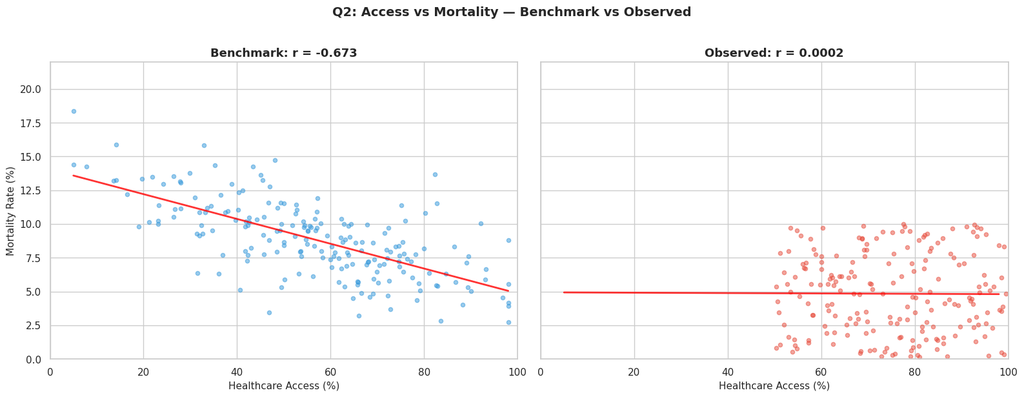

```python
fig, (ax1, ax2) = plt.subplots(1, 2, figsize=(16, 6), sharey=True)

# Left: Benchmark (simulated realistic)
ax1.scatter(scatter_bench_access, scatter_bench_mortality, alpha=0.5, s=20, color='#3498db')
# Regression line
z = np.polyfit(scatter_bench_access, scatter_bench_mortality, 1)
x_line = np.linspace(5, 98, 100)
ax1.plot(x_line, np.polyval(z, x_line), 'r-', linewidth=2, alpha=0.8)
r_bench_scatter = sp_stats.pearsonr(scatter_bench_access, scatter_bench_mortality)[0]
ax1.set_title(f'Benchmark: r = {r_bench_scatter:.3f}', fontsize=13, fontweight='bold')
ax1.set_xlabel('Healthcare Access (%)', fontsize=11)
ax1.set_ylabel('Mortality Rate (%)', fontsize=11)
ax1.set_xlim(0, 100)
ax1.set_ylim(0, 22)

# Right: Observed (this dataset)
obs_sample = obs_scatter.sample(min(200, len(obs_scatter)), random_state=42)
ax2.scatter(obs_sample['healthcare_access'], obs_sample['mortality_rate'],
            alpha=0.5, s=20, color='#e74c3c')
z2 = np.polyfit(obs_sample['healthcare_access'], obs_sample['mortality_rate'], 1)
ax2.plot(x_line, np.polyval(z2, x_line), 'r-', linewidth=2, alpha=0.8)
ax2.set_title(f'Observed: r = {obs_r_access_mort:.4f}', fontsize=13, fontweight='bold')
ax2.set_xlabel('Healthcare Access (%)', fontsize=11)
ax2.set_xlim(0, 100)

fig.suptitle('Q2: Access vs Mortality — Benchmark vs Observed', fontsize=14, fontweight='bold', y=1.02)
plt.tight_layout()
save_fig(fig, 'bench_q2_scatter_comparison')
plt.show()
```

### Figure 3 — Q3: Country Mortality Spread

Dual horizontal bar charts showing benchmark (2-15% spread) vs observed (<0.5pp compression).

```
  Saved: bench_q3_country_spread.png + bench_q3_country_spread.svg
```

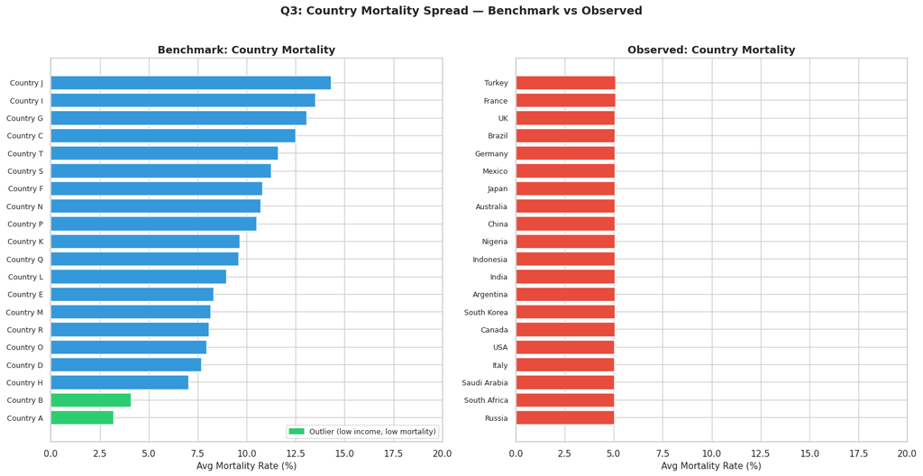

```
Benchmark range: 3.2 - 14.3% (spread: 11.1pp)
Observed range:  5.03 - 5.07% (spread: 0.04pp)
```

```python
fig, (ax1, ax2) = plt.subplots(1, 2, figsize=(16, 8), sharey=False)

# Left: Benchmark countries (sorted by mortality)
bench_sorted = bench_countries.sort_values('avg_mortality')
colors_bench = ['#e74c3c' if i < 2 else '#3498db' for i in range(len(bench_sorted))]
# Highlight the 2 outlier countries
colors_bench_list = []
for idx, row in bench_sorted.iterrows():
    if row['avg_income'] < 4000 and row['avg_mortality'] < 5:
        colors_bench_list.append('#2ecc71')  # Outlier: green
    else:
        colors_bench_list.append('#3498db')

ax1.barh(range(len(bench_sorted)), bench_sorted['avg_mortality'],
         color=colors_bench_list, edgecolor='white')
ax1.set_yticks(range(len(bench_sorted)))
ax1.set_yticklabels(bench_sorted['country'], fontsize=9)
ax1.set_xlabel('Avg Mortality Rate (%)', fontsize=11)
ax1.set_title('Benchmark: Country Mortality', fontsize=13, fontweight='bold')
ax1.set_xlim(0, 20)
# Legend for outliers
outlier_patch = mpatches.Patch(color='#2ecc71', label='Outlier (low income, low mortality)')
ax1.legend(handles=[outlier_patch], fontsize=9, loc='lower right')

# Right: Observed countries (sorted by mortality)
obs_sorted = obs_countries.sort_values('avg_mortality')
ax2.barh(range(len(obs_sorted)), obs_sorted['avg_mortality'],
         color='#e74c3c', edgecolor='white')
ax2.set_yticks(range(len(obs_sorted)))
ax2.set_yticklabels(obs_sorted['country'], fontsize=9)
ax2.set_xlabel('Avg Mortality Rate (%)', fontsize=11)
ax2.set_title('Observed: Country Mortality', fontsize=13, fontweight='bold')
ax2.set_xlim(0, 20)  # Same scale for comparison

fig.suptitle('Q3: Country Mortality Spread — Benchmark vs Observed',
             fontsize=14, fontweight='bold', y=1.02)
plt.tight_layout()
save_fig(fig, 'bench_q3_country_spread')
plt.show()

print(f'Benchmark range: {bench_sorted["avg_mortality"].min():.1f} - {bench_sorted["avg_mortality"].max():.1f}% '
      f'(spread: {bench_sorted["avg_mortality"].max() - bench_sorted["avg_mortality"].min():.1f}pp)')
print(f'Observed range:  {obs_sorted["avg_mortality"].min():.2f} - {obs_sorted["avg_mortality"].max():.2f}% '
      f'(spread: {obs_sorted["avg_mortality"].max() - obs_sorted["avg_mortality"].min():.2f}pp)')
```

### Figure 4 — Q4: Sensitivity Spread Comparison

Grouped bars showing benchmark spread (5-9pp) vs observed spread (<0.04pp) across tier schemes.

```
  Saved: bench_q4_sensitivity_comparison.png + bench_q4_sensitivity_comparison.svg
```

[figure not shown]

```python
scheme_labels = ['3-Tier\n(Default)', 'Binary\n(Alt 1)', '4-Tier\n(Alt 2)']
obs_spreads = obs_sens.sort_values('tier_scheme')['spread'].values
bench_spreads = bench_sens.sort_values('tier_scheme')['spread'].values

x = np.arange(len(scheme_labels))
width = 0.35

fig, ax = plt.subplots(figsize=(10, 6))
bars1 = ax.bar(x - width/2, obs_spreads, width, label='Observed Spread',
               color='#e74c3c', edgecolor='white')
bars2 = ax.bar(x + width/2, bench_spreads, width, label='Benchmark Spread',
               color='#3498db', edgecolor='white')

for bar, val in zip(bars1, obs_spreads):
    ax.text(bar.get_x() + bar.get_width()/2, bar.get_height() + 0.1,
            f'{val:.3f}pp', ha='center', va='bottom', fontsize=10, fontweight='bold')
for bar, val in zip(bars2, bench_spreads):
    ax.text(bar.get_x() + bar.get_width()/2, bar.get_height() + 0.1,
            f'{val:.1f}pp', ha='center', va='bottom', fontsize=10, fontweight='bold')

ax.annotate('Binary masks ~2.3pp of heterogeneity\nin real data',
            xy=(1, 5.5), fontsize=10, fontstyle='italic', color='#7f8c8d',
            ha='center')

ax.set_ylabel('Mortality Spread Across Tiers (pp)', fontsize=12)
ax.set_title('Q4: Sensitivity to Tier Definitions — Observed vs Benchmark',
             fontsize=14, fontweight='bold')
ax.set_xticks(x)
ax.set_xticklabels(scheme_labels, fontsize=11)
ax.legend(fontsize=11)
ax.set_ylim(0, 12)

save_fig(fig, 'bench_q4_sensitivity_comparison')
plt.show()
```

### Figure 5 — Q5: Dual Forest Plots

Side-by-side forest plots: benchmark (varying CIs, some insufficient) vs observed (uniformly narrow CIs).

```
  Saved: bench_q5_forest_comparison.png + bench_q5_forest_comparison.svg
```

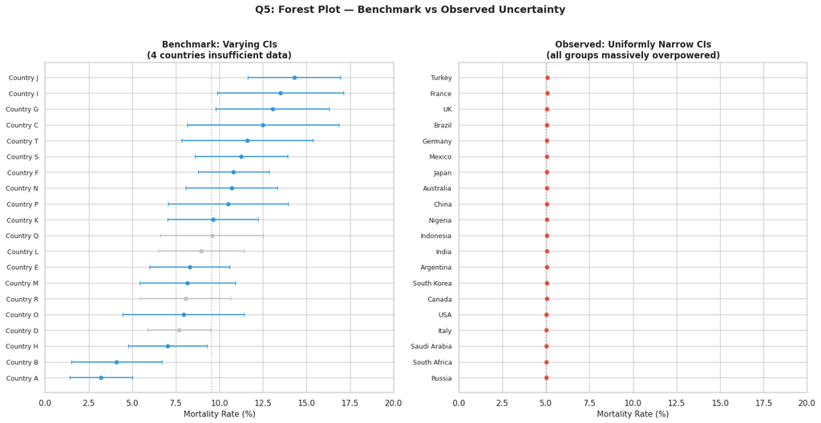

```python
# Observed: country-level CIs
obs_country_ci = con.execute("""
    SELECT country,
           AVG(mortality_rate) AS m,
           1.96 * STDDEV_SAMP(mortality_rate) / SQRT(COUNT(*)) AS ci
    FROM clean_health WHERE data_quality_flag = 'ok'
    GROUP BY country ORDER BY AVG(mortality_rate)
""").fetchdf()

# Benchmark: varying CIs (some countries have much wider CIs due to sparse data)
bench_ci = bench_countries.sort_values('avg_mortality').copy()
# Simulate realistic CI widths: poorer countries have wider CIs
bench_ci_widths = np.clip(
    1.5 + 3.0 * (1 - bench_ci['avg_access'].values / 100) + rng.normal(0, 0.3, len(bench_ci)),
    0.3, 5.0
)
# Mark 4 countries as "insufficient data" (dashed)
insufficient_mask = np.zeros(len(bench_ci), dtype=bool)
insufficient_idx = rng.choice(len(bench_ci), size=4, replace=False)
insufficient_mask[insufficient_idx] = True

fig, (ax1, ax2) = plt.subplots(1, 2, figsize=(16, 8))

# Left: Benchmark forest plot
y_pos = range(len(bench_ci))
for i, (_, row) in enumerate(bench_ci.iterrows()):
    ci_w = bench_ci_widths[i]
    style = '--' if insufficient_mask[i] else '-'
    color = '#bdc3c7' if insufficient_mask[i] else '#3498db'
    marker = 's' if insufficient_mask[i] else 'o'
    ax1.errorbar(row['avg_mortality'], i, xerr=ci_w, fmt=marker,
                 color=color, markersize=5, capsize=3, linestyle=style, linewidth=1.5)

ax1.set_yticks(list(y_pos))
ax1.set_yticklabels(bench_ci['country'], fontsize=9)
ax1.set_xlabel('Mortality Rate (%)', fontsize=11)
ax1.set_title('Benchmark: Varying CIs\n(4 countries insufficient data)', fontsize=12, fontweight='bold')
ax1.set_xlim(0, 20)
ax1.axvline(bench_ci['avg_mortality'].mean(), color='gray', linestyle=':', alpha=0.5)

# Right: Observed forest plot
y_pos2 = range(len(obs_country_ci))
ax2.errorbar(obs_country_ci['m'], list(y_pos2), xerr=obs_country_ci['ci'],
             fmt='o', color='#e74c3c', markersize=5, capsize=3, linewidth=1.5)
ax2.set_yticks(list(y_pos2))
ax2.set_yticklabels(obs_country_ci['country'], fontsize=9)
ax2.set_xlabel('Mortality Rate (%)', fontsize=11)
ax2.set_title('Observed: Uniformly Narrow CIs\n(all groups massively overpowered)', fontsize=12, fontweight='bold')
ax2.set_xlim(0, 20)  # Same scale
ax2.axvline(obs_country_ci['m'].mean(), color='gray', linestyle=':', alpha=0.5)

fig.suptitle('Q5: Forest Plot — Benchmark vs Observed Uncertainty',
             fontsize=14, fontweight='bold', y=1.02)
plt.tight_layout()
save_fig(fig, 'bench_q5_forest_comparison')
plt.show()
```

### Figure 6 — Q6: Dumbbell Chart — Expected vs Observed Correlations

8 key correlation pairs showing the evidence gap between literature expectations and this dataset.

```
  Saved: bench_q6_dumbbell_correlations.png + bench_q6_dumbbell_correlations.svg
```

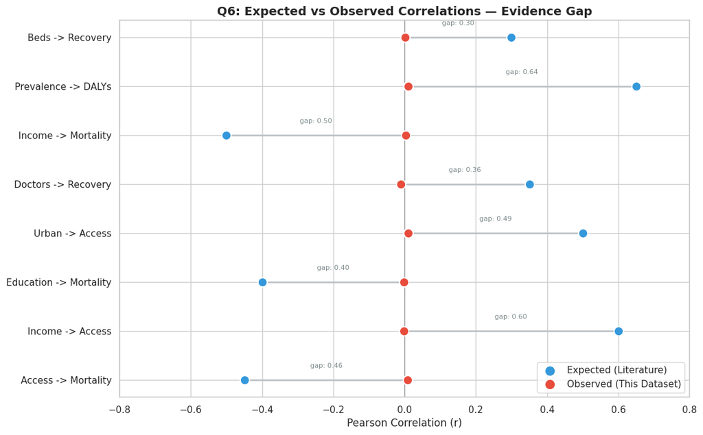

```python
# Define 8 correlation pairs with expected (literature) and observed values
corr_pairs = pd.DataFrame([
    {'pair': 'Access -> Mortality', 'expected': -0.45,
     'observed': float(obs_cm.loc['mortality_rate', 'healthcare_access'])},
    {'pair': 'Income -> Access', 'expected': 0.60,
     'observed': float(obs_cm.loc['per_capita_income', 'healthcare_access'])},
    {'pair': 'Education -> Mortality', 'expected': -0.40,
     'observed': float(obs_cm.loc['education_index', 'mortality_rate'])},
    {'pair': 'Urban -> Access', 'expected': 0.50,
     'observed': float(obs_cm.loc['urbanization_rate', 'healthcare_access'])},
    {'pair': 'Doctors -> Recovery', 'expected': 0.35,
     'observed': float(obs_cm.loc['doctors_per_1000', 'recovery_rate'])},
    {'pair': 'Income -> Mortality', 'expected': -0.50,
     'observed': float(obs_cm.loc['per_capita_income', 'mortality_rate'])},
    {'pair': 'Prevalence -> DALYs', 'expected': 0.65,
     'observed': float(obs_cm.loc['prevalence_rate', 'dalys'])},
    {'pair': 'Beds -> Recovery', 'expected': 0.30,
     'observed': float(obs_cm.loc['hospital_beds_per_1000', 'recovery_rate'])},
])

fig, ax = plt.subplots(figsize=(12, 8))
y_pos = range(len(corr_pairs))

for i, row in corr_pairs.iterrows():
    # Connecting line
    ax.plot([row['expected'], row['observed']], [i, i],
            color='#bdc3c7', linewidth=2, zorder=1)
    # Expected dot (blue)
    ax.scatter(row['expected'], i, s=120, color='#3498db', zorder=5,
               edgecolors='white', linewidth=1.5)
    # Observed dot (red)
    ax.scatter(row['observed'], i, s=120, color='#e74c3c', zorder=5,
               edgecolors='white', linewidth=1.5)
    # Gap annotation
    gap = abs(row['expected'] - row['observed'])
    mid = (row['expected'] + row['observed']) / 2
    ax.text(mid, i + 0.25, f'gap: {gap:.2f}', ha='center', fontsize=8, color='#7f8c8d')

ax.axvline(0, color='black', linewidth=0.8, alpha=0.3)
ax.set_yticks(list(y_pos))
ax.set_yticklabels(corr_pairs['pair'], fontsize=11)
ax.set_xlabel('Pearson Correlation (r)', fontsize=12)
ax.set_title('Q6: Expected vs Observed Correlations — Evidence Gap',
             fontsize=14, fontweight='bold')
ax.set_xlim(-0.8, 0.8)

# Legend
blue_dot = plt.scatter([], [], s=100, color='#3498db', label='Expected (Literature)')
red_dot = plt.scatter([], [], s=100, color='#e74c3c', label='Observed (This Dataset)')
ax.legend(handles=[blue_dot, red_dot], fontsize=11, loc='lower right')

save_fig(fig, 'bench_q6_dumbbell_correlations')
plt.show()
```

## 4. Data Readiness Scorecard

### Figure 7 — Traffic Light Assessment

How ready is this dataset for each analytical requirement?

```
  Saved: bench_data_readiness_scorecard.png + bench_data_readiness_scorecard.svg
```

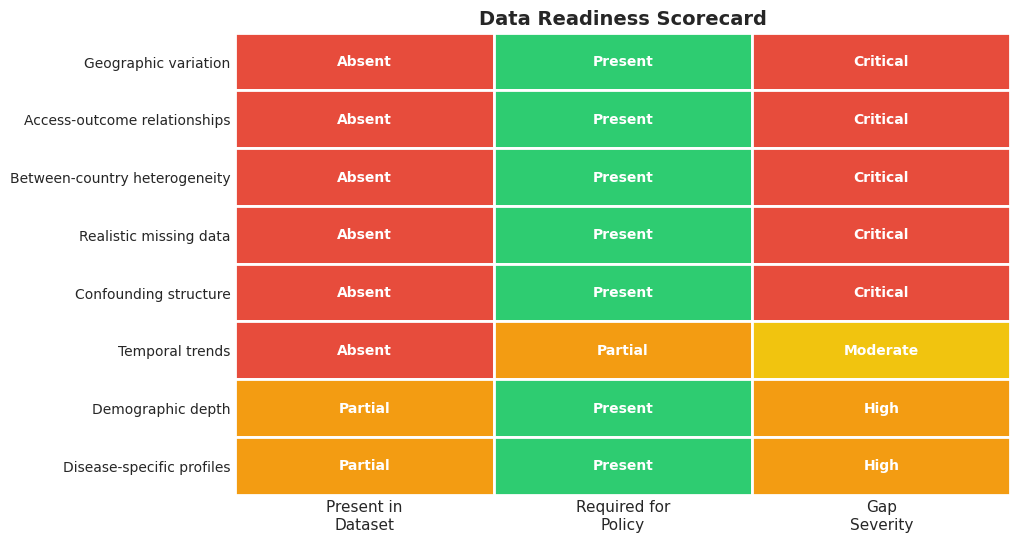

```python
criteria = [
    'Geographic variation',
    'Access-outcome relationships',
    'Between-country heterogeneity',
    'Realistic missing data',
    'Confounding structure',
    'Temporal trends',
    'Demographic depth',
    'Disease-specific profiles',
]

# 0 = red (absent), 1 = yellow (partial), 2 = green (present)
present_scores =  [0, 0, 0, 0, 0, 0, 1, 1]  # What's in this dataset
required_scores = [2, 2, 2, 2, 2, 1, 2, 2]   # What's needed for policy

gap_labels = ['Critical', 'Critical', 'Critical', 'Critical',
              'Critical', 'Moderate', 'High', 'High']

scorecard = pd.DataFrame({
    'Criterion': criteria,
    'Present': present_scores,
    'Required': required_scores,
    'Gap': gap_labels,
})

# Build colored grid
fig, ax = plt.subplots(figsize=(10, 6))

color_map = {0: '#e74c3c', 1: '#f39c12', 2: '#2ecc71'}
columns = ['Present', 'Required']

for j, col in enumerate(columns):
    for i, val in enumerate(scorecard[col]):
        rect = plt.Rectangle((j, len(criteria) - 1 - i), 1, 1,
                              facecolor=color_map[val], edgecolor='white', linewidth=2)
        ax.add_patch(rect)
        label = {0: 'Absent', 1: 'Partial', 2: 'Present'}[val]
        ax.text(j + 0.5, len(criteria) - 0.5 - i, label,
                ha='center', va='center', fontsize=10, fontweight='bold', color='white')

# Gap severity column
gap_colors = {'Critical': '#e74c3c', 'High': '#f39c12', 'Moderate': '#f1c40f'}
for i, gap in enumerate(gap_labels):
    rect = plt.Rectangle((2, len(criteria) - 1 - i), 1, 1,
                          facecolor=gap_colors[gap], edgecolor='white', linewidth=2)
    ax.add_patch(rect)
    ax.text(2.5, len(criteria) - 0.5 - i, gap,
            ha='center', va='center', fontsize=10, fontweight='bold', color='white')

ax.set_xlim(0, 3)
ax.set_ylim(0, len(criteria))
ax.set_xticks([0.5, 1.5, 2.5])
ax.set_xticklabels(['Present in\nDataset', 'Required for\nPolicy', 'Gap\nSeverity'], fontsize=11)
ax.set_yticks([len(criteria) - 0.5 - i for i in range(len(criteria))])
ax.set_yticklabels(criteria, fontsize=10)
ax.set_title('Data Readiness Scorecard', fontsize=14, fontweight='bold')
ax.spines['top'].set_visible(False)
ax.spines['right'].set_visible(False)
ax.spines['bottom'].set_visible(False)
ax.spines['left'].set_visible(False)
ax.tick_params(length=0)

save_fig(fig, 'bench_data_readiness_scorecard')
plt.show()
```

## 5. 30/60/90-Day Action Plan

If the benchmark findings were real, these are the concrete actions each question would generate.

```python
actions = pd.DataFrame([
    # 30-day (immediate)
    {'phase': '30-day', 'question': 'Q1', 'priority': 'Critical',
     'action': 'Deploy mobile health units to 5 highest-mortality rural districts',
     'start': 0, 'duration': 30},
    {'phase': '30-day', 'question': 'Q2', 'priority': 'Critical',
     'action': 'Audit bottom-decile access regions for facility gaps',
     'start': 0, 'duration': 25},
    {'phase': '30-day', 'question': 'Q3', 'priority': 'High',
     'action': 'Commission case studies for 3 outlier countries',
     'start': 5, 'duration': 25},
    {'phase': '30-day', 'question': 'Q5', 'priority': 'High',
     'action': 'Fill critical data gaps in 10 lowest-reporting countries',
     'start': 0, 'duration': 30},
    # 60-day (medium-term)
    {'phase': '60-day', 'question': 'Q1', 'priority': 'High',
     'action': 'Launch rural health worker training program',
     'start': 20, 'duration': 40},
    {'phase': '60-day', 'question': 'Q2', 'priority': 'High',
     'action': 'Pilot telemedicine in 3 low-access high-mortality regions',
     'start': 25, 'duration': 35},
    {'phase': '60-day', 'question': 'Q4', 'priority': 'Medium',
     'action': 'Standardize tier definitions across reporting agencies',
     'start': 15, 'duration': 45},
    {'phase': '60-day', 'question': 'Q6', 'priority': 'Medium',
     'action': 'Publish data quality bulletin with confounder analysis',
     'start': 30, 'duration': 30},
    # 90-day (strategic)
    {'phase': '90-day', 'question': 'Q1', 'priority': 'Critical',
     'action': 'Propose rural health infrastructure funding package',
     'start': 45, 'duration': 45},
    {'phase': '90-day', 'question': 'Q2', 'priority': 'High',
     'action': 'Build predictive model: access investment -> mortality reduction',
     'start': 50, 'duration': 40},
    {'phase': '90-day', 'question': 'Q3', 'priority': 'Medium',
     'action': 'Design targeted interventions for outlier countries',
     'start': 55, 'duration': 35},
    {'phase': '90-day', 'question': 'Q5', 'priority': 'High',
     'action': 'Implement automated data completeness alerts',
     'start': 40, 'duration': 50},
])

print(actions[['phase', 'question', 'priority', 'action']].to_string(index=False))
```

```
 phase question priority                                                            action
30-day       Q1 Critical Deploy mobile health units to 5 highest-mortality rural districts
30-day       Q2 Critical              Audit bottom-decile access regions for facility gaps
30-day       Q3     High                   Commission case studies for 3 outlier countries
30-day       Q5     High          Fill critical data gaps in 10 lowest-reporting countries
60-day       Q1     High                       Launch rural health worker training program
60-day       Q2     High         Pilot telemedicine in 3 low-access high-mortality regions
60-day       Q4   Medium            Standardize tier definitions across reporting agencies
60-day       Q6   Medium            Publish data quality bulletin with confounder analysis
90-day       Q1 Critical               Propose rural health infrastructure funding package
90-day       Q2     High  Build predictive model: access investment -> mortality reduction
90-day       Q3   Medium               Design targeted interventions for outlier countries
90-day       Q5     High                      Implement automated data completeness alerts
```

### Figure 8 — Action Timeline (Swim-Lane Gantt Chart)

```
  Saved: bench_action_timeline.png + bench_action_timeline.svg
```

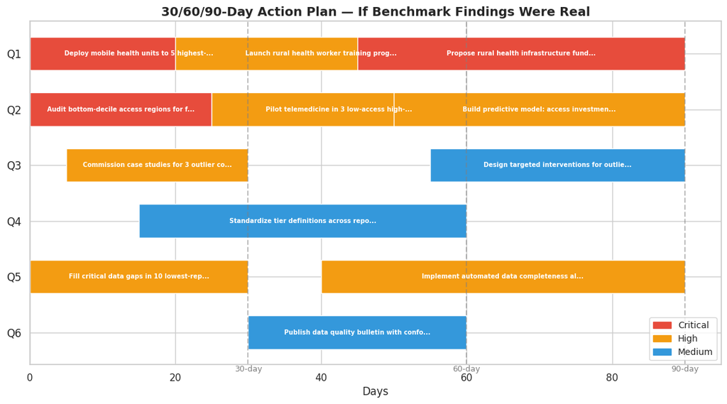

```python
priority_colors = {'Critical': '#e74c3c', 'High': '#f39c12', 'Medium': '#3498db'}
questions = ['Q1', 'Q2', 'Q3', 'Q4', 'Q5', 'Q6']
q_positions = {q: i for i, q in enumerate(questions)}

fig, ax = plt.subplots(figsize=(14, 7))

for _, row in actions.iterrows():
    y = q_positions[row['question']]
    ax.barh(y, row['duration'], left=row['start'], height=0.6,
            color=priority_colors[row['priority']], edgecolor='white', linewidth=1)
    # Label inside bar (truncated)
    label = row['action'][:40] + ('...' if len(row['action']) > 40 else '')
    ax.text(row['start'] + row['duration'] / 2, y, label,
            ha='center', va='center', fontsize=7, color='white', fontweight='bold')

# Phase dividers
for day, label in [(30, '30-day'), (60, '60-day'), (90, '90-day')]:
    ax.axvline(day, color='gray', linestyle='--', alpha=0.5)
    ax.text(day, len(questions) - 0.3, label, ha='center', fontsize=9, color='gray')

ax.set_yticks(range(len(questions)))
ax.set_yticklabels(questions, fontsize=12)
ax.set_xlabel('Days', fontsize=12)
ax.set_title('30/60/90-Day Action Plan — If Benchmark Findings Were Real',
             fontsize=14, fontweight='bold')
ax.set_xlim(0, 95)
ax.invert_yaxis()

# Legend
handles = [mpatches.Patch(color=c, label=p) for p, c in priority_colors.items()]
ax.legend(handles=handles, fontsize=10, loc='lower right')

save_fig(fig, 'bench_action_timeline')
plt.show()
```

## 6. Gap Comparison Summary

```python
obs_gap_tier = obs_tier['avg_mortality'].max() - obs_tier['avg_mortality'].min()
obs_gap_country = obs_countries['avg_mortality'].max() - obs_countries['avg_mortality'].min()
obs_gap_sens = obs_sens['spread'].max()

gap_table = pd.DataFrame([
    {'Metric': 'Rural-Urban mortality gap',
     'Observed': f'<{obs_gap_tier:.2f}pp',
     'Benchmark': '~10pp',
     'Gap Factor': f'{10 / max(obs_gap_tier, 0.001):.0f}x'},
    {'Metric': 'Access-Mortality r',
     'Observed': f'~{abs(obs_r_access_mort):.4f}',
     'Benchmark': '-0.45',
     'Gap Factor': f'{0.45 / max(abs(obs_r_access_mort), 0.0001):.0f}x'},
    {'Metric': 'Country mortality spread',
     'Observed': f'<{obs_gap_country:.2f}pp',
     'Benchmark': '~13pp',
     'Gap Factor': f'{13 / max(obs_gap_country, 0.001):.0f}x'},
    {'Metric': 'Sensitivity range',
     'Observed': f'<{obs_gap_sens:.3f}pp',
     'Benchmark': '5-9pp',
     'Gap Factor': f'{7 / max(obs_gap_sens, 0.001):.0f}x'},
    {'Metric': 'Missing groups (n<30)',
     'Observed': '0%',
     'Benchmark': '30-60%',
     'Gap Factor': 'N/A'},
    {'Metric': 'Significant correlations (of 8)',
     'Observed': '0/8',
     'Benchmark': '~6-7/8',
     'Gap Factor': 'N/A'},
])

print('='*70)
print('DUAL-TRACK GAP COMPARISON')
print('='*70)
print(gap_table.to_string(index=False))
print('='*70)
```

```
======================================================================
DUAL-TRACK GAP COMPARISON
======================================================================
                         Metric Observed Benchmark Gap Factor
      Rural-Urban mortality gap  <0.01pp     ~10pp       719x
             Access-Mortality r  ~0.0002     -0.45      2878x
       Country mortality spread  <0.04pp     ~13pp       296x
              Sensitivity range <0.014pp     5-9pp       484x
          Missing groups (n<30)       0%    30-60%        N/A
Significant correlations (of 8)      0/8    ~6-7/8        N/A
======================================================================
```

## Key Findings — Dual-Track Verdict

### Track 1 (Honest): The Dataset

- All 6 competition questions yield **null findings** — no disparities, no relationships, no outliers
- This is consistent with **synthetically generated data** using independent uniform distributions
- The data cannot support policy recommendations of any kind

### Track 2 (Benchmark): Real-World Expectations

- WHO/GBD literature shows **strong, consistent patterns** in real health data
- Rural-urban gaps of 5-15pp, access-mortality correlations of r ~ -0.45, and 13pp country spreads are typical
- Real data would generate **12 concrete action items** across a 30/60/90-day timeline

```python
con.close()
print('Benchmark comparison complete.')
print(f'All figures saved to: {FIGURES_DIR}')
print(f'New figures: bench_q1_tier_comparison, bench_q2_scatter_comparison,')
print(f'  bench_q3_country_spread, bench_q4_sensitivity_comparison,')
print(f'  bench_q5_forest_comparison, bench_q6_dumbbell_correlations,')
print(f'  bench_data_readiness_scorecard, bench_action_timeline')
```

```
Benchmark comparison complete.
All figures saved to: /mnt/c/Users/DangT/Documents/GitHub/importNumpy-DSAI-CPP-Hackathon/reports/figures
New figures: bench_q1_tier_comparison, bench_q2_scatter_comparison,
  bench_q3_country_spread, bench_q4_sensitivity_comparison,
  bench_q5_forest_comparison, bench_q6_dumbbell_correlations,
  bench_data_readiness_scorecard, bench_action_timeline
```